# Проект ''Оценка возраста покупателей''

Сетевой супермаркет внедряет систему компьютерного зрения для обработки фотографий покупателей. Фотофиксация в прикассовой зоне поможет определять возраст клиентов, чтобы: · Анализировать покупки и предлагать товары, которые могут заинтересовать покупателей этой возрастной группы; · Контролировать добросовестность кассиров при продаже алкоголя.

**Дано:** набор фотографий людей с указанием возраста

**Требуется:** модель, которая по фотографии определит приблизительный возраст человека

## Исследовательский анализ данных

### Импорты и настройки

```python
import pandas            as pd
import matplotlib.pyplot as plt
import seaborn           as sns

from tensorflow.keras.preprocessing.image import ImageDataGenerator
```

### Загрузка данных

```python
labels = pd.read_csv('/datasets/faces/labels.csv')
```

```python
train_datagen  = ImageDataGenerator(rescale=1./255)
train_gen_flow = train_datagen.flow_from_dataframe(
        dataframe  =labels,
        directory  ='/datasets/faces/final_files/',
        x_col      ='file_name',
        y_col      ='real_age',
        target_size=(224, 224),
        batch_size =32,
        class_mode ='raw',
        seed       =2022_08_02)

features, target = next(train_gen_flow)
```

```
Found 7591 validated image filenames.
```

### Обзор данных

```python
labels
```

|  | file_name | real_age |
| --- | --- | --- |
| 0 | 000000.jpg | 4 |
| 1 | 000001.jpg | 18 |
| 2 | 000002.jpg | 80 |
| 3 | 000003.jpg | 50 |
| 4 | 000004.jpg | 17 |
| ... | ... | ... |
| 7586 | 007608.jpg | 14 |
| 7587 | 007609.jpg | 37 |
| 7588 | 007610.jpg | 28 |
| 7589 | 007611.jpg | 20 |
| 7590 | 007612.jpg | 47 |

7591 rows × 2 columns

```python
labels.info()
```

```
<class 'pandas.core.frame.DataFrame'>
RangeIndex: 7591 entries, 0 to 7590
Data columns (total 2 columns):
 #   Column     Non-Null Count  Dtype
---  ------     --------------  -----
 0   file_name  7591 non-null   object
 1   real_age   7591 non-null   int64
dtypes: int64(1), object(1)
memory usage: 118.7+ KB
```

```python
labels.duplicated().sum()
```

```
0
```

```python
labels.describe().T
```

|  | count | mean | std | min | 25% | 50% | 75% | max |
| --- | --- | --- | --- | --- | --- | --- | --- | --- |
| real_age | 7591.0 | 31.201159 | 17.14506 | 1.0 | 20.0 | 29.0 | 41.0 | 100.0 |

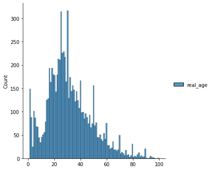

```python
sns.displot(labels, bins=100)
```

**Замечания:**

- в датафрейме 7591 строка;
- наименования файлов в начале датафрейма соответствуют попорядковому номеру в датафрейме, но в конце датафрейма число в названии файла несколько превышает номер в двтвфрейме;
- явные пропуски и дубликаты отсутствуют;
- минимальный возраст (целевой признак) всего 1(один) год; максимальный возраст - 100 лет; медианное значени 29 лет;
- Распределение возрастов в имеет два явных пика: большой в районе медианного значения и малый - в районе 5...6 лет

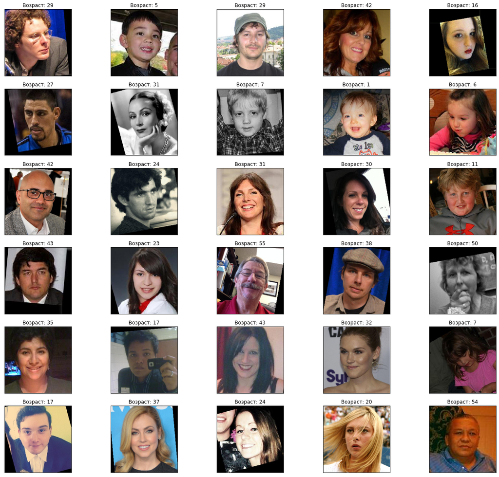

```python
fig = plt.figure(figsize=(20,16))
for i in range(30):
    fig.add_subplot(6, 5, i+1)
    plt.imshow(features[i])
    plt.xticks([])
    plt.yticks([])
    plt.tight_layout()
    plt.title('Возраст: ' + str(target[i]))
```

**Замечания:**

- имеются как цветные так и черно-белые фотографии;
- присутствуют повернутые и сдвинутые изображения;
- присутствуют изображения в профиль и анфас

# Выводы

- распределение исходных данных неравномерно и смещено в сторону "критического" значения - возраста совершеннолетия (т.е. пожилых существенно меньше, чем детей), что предпочтительно для целей создания модели;
- судя по наличию "сдвинутых" и "повернутых" изображений в данных, над ними уже проведена операция аугментации, что должно благоприятно сказаться на качестве обучения модели;
- весомых причин для проведения дополнительной предъобработки исходных данных не выявлено

## Обучение модели

В этом разделе код оформлен в виде текстовых ячеек, так как приведен для иллюстрации. Выполнение кода производилось в отдельном GPU-тренажёре

```
import pandas as pd

from tensorflow.keras.preprocessing.image import ImageDataGenerator
from tensorflow.keras.applications.resnet import ResNet50
from tensorflow.keras.models              import Sequential
from tensorflow.keras.layers              import GlobalAveragePooling2D, Dense
from tensorflow.keras.optimizers          import Adam
```

```
optimizer = Adam(learning_rate=0.0001)
```

```
def load_train(path):
    labels             = pd.read_csv(path + 'labels.csv')
    train_datagen      = ImageDataGenerator(validation_split  =0.25,
                                            horizontal_flip   =True,
#                                            vertical_flip     =True,
#                                            width_shift_range =0.2,
#                                            height_shift_range=0.2,
                                            rescale           =1./255)
    train_datagen_flow = train_datagen.flow_from_dataframe(
        dataframe  =labels,
        directory  =path + 'final_files/',
        x_col      ='file_name',
        y_col      ='real_age',
        target_size=(150, 150),
        batch_size =16,
        class_mode ='raw',
        subset     ='training',
        seed       =2022_08_02
    )
    return train_datagen_flow
```

```
def load_test(path):
    labels            = pd.read_csv(path + 'labels.csv')
    test_datagen      = ImageDataGenerator(validation_split  =0.25,
                                           rescale           =1./255)
    test_datagen_flow = test_datagen.flow_from_dataframe(
        dataframe  =labels,
        directory  =path + 'final_files/',
        x_col      ='file_name',
        y_col      ='real_age',
        target_size=(150, 150),
        batch_size =16,
        class_mode ='raw',
        subset     ='validation',
        seed       =2022_08_02
    )
    return test_datagen_flow
```

```
def create_model(input_shape):

    backbone  = ResNet50(input_shape=input_shape,
#                         classes    =1,
                         weights    ='imagenet',
                         include_top=False)
    model     = Sequential()
    model.add(backbone)
    model.add(GlobalAveragePooling2D())
    model.add(Dense(units     =1,
                    activation='relu'))

    model.compile(loss     ='mse',
                  optimizer=optimizer,
                  metrics  =['mae'])

    return model
```

```
def train_model(model,
                train_data,
                test_data,
                batch_size      =None,
                epochs          =5,
                steps_per_epoch =None,
                validation_steps=None):

    if steps_per_epoch is None:
        steps_per_epoch  = len(train_data)
    if validation_steps is None:
        validation_steps = len(test_data)

    model.fit(train_data,
              validation_data =test_data,
              batch_size      =batch_size,
              epochs          =epochs,
              steps_per_epoch =steps_per_epoch,
              validation_steps=validation_steps,
              verbose         =2,
              shuffle         =True)

    return model
```

```
Found 5694 validated image filenames.
Found 1897 validated image filenames.

<class 'tensorflow.python.keras.engine.sequential.Sequential'>

Train for 356 steps, validate for 119 steps
Epoch 1/5
356/356 - 65s - loss: 240.9496 - mae: 11.2209 - val_loss: 663.9485 - val_mae: 20.6410
Epoch 2/5
356/356 - 36s - loss: 87.2493 - mae: 7.1479 - val_loss: 133.1665 - val_mae: 8.7129
Epoch 3/5
356/356 - 36s - loss: 61.7541 - mae: 5.9738 - val_loss: 80.9150 - val_mae: 6.7345
Epoch 4/5
356/356 - 36s - loss: 44.3005 - mae: 5.0556 - val_loss: 83.3129 - val_mae: 6.9408
Epoch 5/5
356/356 - 36s - loss: 30.4099 - mae: 4.2059 - val_loss: 75.6090 - val_mae: 6.5269

119/119 - 9s - loss: 75.6090 - mae: 6.5269
Test MAE: 6.5269
```

## Анализ обученной модели

В средем модель ошибается на 6,53 лет.

Модель на основе ResNet50 обучена за 5 эпох:

- в качестве стартовых весов модели ResNet50 инициализированы веса `ImageNet`;
- последние слои ResNet50 с отключенны;
- к ResNet50 добавлен верхний полносвязный слой с активатором `ReLu`;
- функция потерь при обучении модели - среднеквадратичная (`MSE`);
- оптимизатор `Adam` c шагом спуска 0.0001

Возможно, увеличение количества эпох позволило бы улучшить метрики.

Дополнительная аугментация изображений посредством сдвигов (по ширине или высоте) приводит к ухудшению целевой метрики при прочих равных.

Ограничение количества классов изображений в ResNet50 приводит к ухудшению целевой метрики при прочих равных.

Возможно, в виду целевого применения в магазине для определения критического возраста, модель следовало бы преобразовать в модель классификации. Классов можно реализовать больше двух (`совершеннолетние` и `несовершеннолетние`), а также с большей градацией по возрасту (`пожилые`, `зрелые`, `молодые`, `подростки` и `малолетние`) и по полу (`М` и `Ж`), но для этого предварительно потребуется провести работы по разметке целевого признака.